# Beta-2-microglobulin

## Figure 6: Deep-MSA contact map panel / Best clusters contact map panel

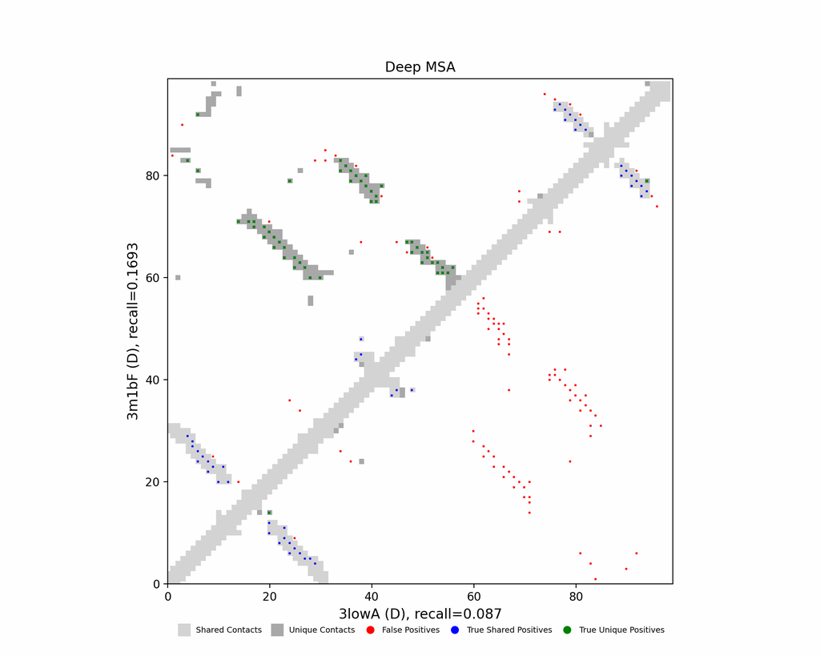

Deep-MSA contact map panel

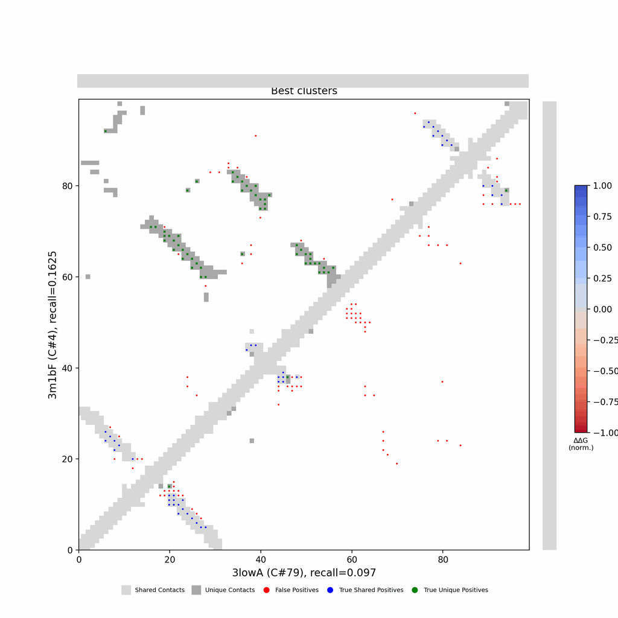

Best clusters contact map panel

## Figure 7: All clusters contact-map mosaic (small multiples).

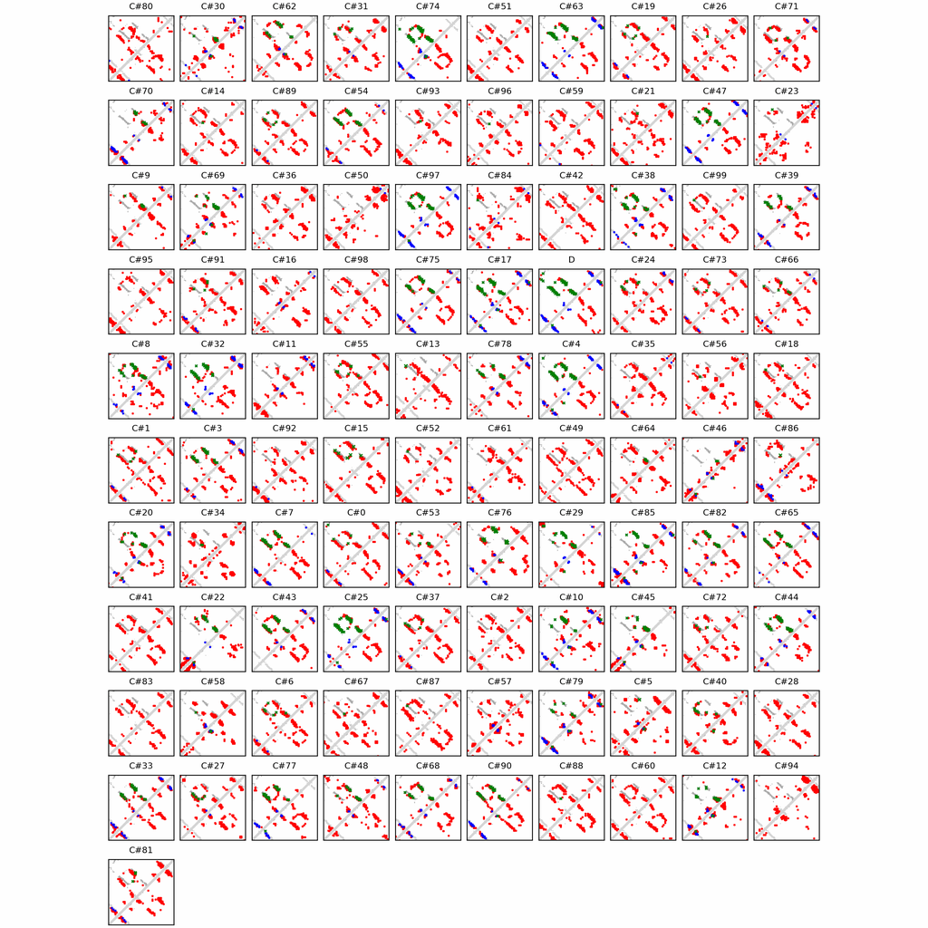

## Figure 8: Phylo null: tree with shuffled cluster fold labels.

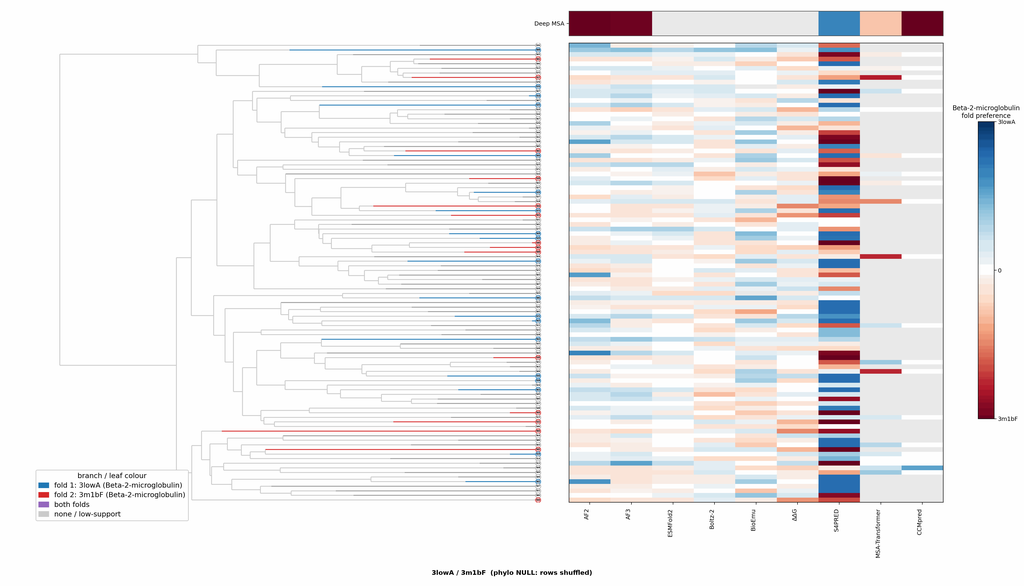

## Cluster metrics table

Per-cluster metrics underlying the figures above.

| cluster | n | neff | AF2_TM1 | AF2_TM2 | AF3_TM1 | AF3_TM2 | RE-MSAT-COM | RE-MSAT1 | RE-MSAT2 | ESM_SEQIDS | ESM_TM1 | ESM_TM2 | ΔΔG_Bias | ΔΔG_Bias_std | ΔΔG_frac_F1 | Boltz2_pref | S4PRED_pref | CCMpred_pref | BioEmu_pref |
| --- | --- | --- | --- | --- | --- | --- | --- | --- | --- | --- | --- | --- | --- | --- | --- | --- | --- | --- | --- |
| Deep | - | - | 0.56 | 0.97 | 0.57 | 0.96 | 0.28 | 0.29 | 0.48 | - | - | - | - | - | - | - | 0.09 | -0.01 | - |
| 000 | 467.0 | 232.0 | 0.43 | 0.76 | 0.5 | 0.86 | 0.02 | 0.02 | 0.04 | 002; 002; 001; 005; 004; 001; 005; 004; 007; 007 | 0.48 ± 0.01 | 0.80 ± 0.03 | 7.46 | 3.25 | 1.0 | -0.36 | -0.04 | 0.0 | -0.25 |
| 001 | 272.0 | 183.0 | 0.37 | 0.69 | 0.42 | 0.74 | 0.02 | 0.02 | 0.06 | 002; 002; 001; 001; 004; 004; 008; 008; 003; 003 | 0.48 ± 0.02 | 0.78 ± 0.02 | 8.41 | 3.0 | 1.0 | -0.34 | -0.07 | 0.0 | -0.25 |
| 002 | 187.0 | 97.0 | 0.41 | 0.63 | 0.39 | 0.6 | 0.0 | 0.0 | 0.0 | 002; 003; 003; 002; 001; 001; 009; 009; 010; 010 | 0.49 ± 0.07 | 0.78 ± 0.14 | 8.95 | 3.67 | 1.0 | -0.22 | -0.12 | 0.0 | -0.16 |
| 003 | 162.0 | 98.0 | 0.41 | 0.75 | 0.42 | 0.76 | 0.03 | 0.03 | 0.1 | 004; 004; 001; 003; 001; 003; 006; 006; 002; 002 | 0.45 ± 0.02 | 0.77 ± 0.04 | 8.77 | 2.77 | 1.0 | -0.31 | 0.12 | 0.0 | -0.3 |
| 004 | 161.0 | 119.0 | 0.29 | 0.5 | 0.31 | 0.55 | 0.18 | 0.19 | 0.42 | 001; 001; 003; 003; 002; 002; 007; 004; 004; 007 | 0.49 ± 0.02 | 0.81 ± 0.04 | 7.35 | 3.59 | 1.0 | -0.31 | 0.01 | 0.0 | -0.15 |
| 005 | 153.0 | 90.0 | 0.32 | 0.52 | 0.37 | 0.62 | 0.0 | 0.03 | 0.0 | 002; 002; 001; 001; 010; 004; 004; 010; 006; 006 | 0.51 ± 0.02 | 0.83 ± 0.06 | 6.76 | 2.24 | 1.0 | -0.28 | -0.12 | 0.0 | -0.22 |
| 006 | 151.0 | 68.0 | 0.26 | 0.41 | 0.4 | 0.71 | 0.02 | 0.02 | 0.02 | 002; 002; 006; 005; 006; 005; 003; 003; 001; 001 | 0.47 ± 0.01 | 0.78 ± 0.04 | 8.54 | 1.74 | 1.0 | -0.34 | 0.12 | 0.0 | -0.09 |
| 007 | 150.0 | 68.0 | 0.41 | 0.64 | 0.5 | 0.76 | 0.07 | 0.07 | 0.22 | 005; 005; 006; 006; 010; 007; 007; 010; 009; 009 | 0.48 ± 0.01 | 0.77 ± 0.04 | 8.75 | 2.51 | 1.0 | -0.26 | -0.12 | 0.0 | -0.18 |
| 008 | 141.0 | 23.0 | 0.49 | 0.83 | 0.47 | 0.84 | 0.07 | 0.07 | 0.04 | 008; 008; 002; 002; 005; 005; 001; 001; 010; 010 | 0.48 ± 0.03 | 0.82 ± 0.06 | 5.84 | 1.98 | 1.0 | -0.39 | 0.01 | 0.01 | -0.31 |
| 009 | 137.0 | 51.0 | 0.38 | 0.69 | 0.4 | 0.71 | 0.0 | 0.0 | 0.01 | 001; 001; 008; 008; 009; 009; 003; 003; 010; 010 | 0.49 ± 0.05 | 0.82 ± 0.11 | 7.15 | 2.84 | 1.0 | -0.33 | 0.02 | 0.0 | -0.08 |
| 010 | 131.0 | 24.0 | 0.42 | 0.77 | 0.43 | 0.83 | 0.18 | 0.18 | 0.17 | 001; 003; 003; 004; 004; 001; 007; 008; 002; 002 | 0.50 ± 0.01 | 0.80 ± 0.02 | 4.38 | 2.81 | 0.9 | -0.39 | 0.06 | 0.0 | -0.16 |
| 011 | 129.0 | 46.0 | 0.36 | 0.54 | 0.43 | 0.76 | 0.0 | 0.0 | 0.0 | 003; 003; 002; 002; 001; 001; 006; 006; 009; 005 | 0.49 ± 0.04 | 0.75 ± 0.16 | 6.17 | 2.06 | 1.0 | -0.35 | -0.07 | 0.0 | -0.12 |
| 012 | 127.0 | 39.0 | 0.33 | 0.56 | 0.35 | 0.62 | 0.0 | 0.02 | 0.0 | 009; 009; 005; 005; 002; 002; 004; 004; 003; 006 | 0.48 ± 0.01 | 0.75 ± 0.06 | 6.22 | 2.11 | 1.0 | -0.3 | 0.02 | 0.0 | -0.17 |
| 013 | 124.0 | 69.0 | 0.39 | 0.57 | 0.25 | 0.35 | 0.0 | 0.0 | 0.0 | 001; 001; 002; 002; 007; 007; 004; 004; 003; 003 | 0.52 ± 0.02 | 0.86 ± 0.09 | 11.25 | 2.83 | 1.0 | -0.18 | -0.12 | 0.0 | -0.14 |
| 014 | 117.0 | 77.0 | 0.38 | 0.65 | 0.45 | 0.72 | 0.0 | 0.0 | 0.01 | 004; 004; 001; 001; 002; 002; 006; 006; 005; 005 | 0.51 ± 0.03 | 0.84 ± 0.05 | 7.58 | 2.95 | 1.0 | -0.29 | 0.08 | 0.0 | -0.2 |
| 015 | 117.0 | 88.0 | 0.34 | 0.58 | 0.34 | 0.56 | 0.0 | 0.0 | 0.02 | 002; 002; 001; 001; 005; 005; 003; 003; 008; 004 | 0.48 ± 0.03 | 0.75 ± 0.12 | 9.28 | 2.78 | 1.0 | -0.25 | 0.04 | 0.0 | -0.19 |
| 016 | 112.0 | 68.0 | 0.37 | 0.66 | 0.28 | 0.61 | 0.02 | 0.02 | 0.01 | 001; 004; 001; 004; 006; 006; 002; 008; 002; 008 | 0.49 ± 0.01 | 0.83 ± 0.03 | 6.87 | 3.26 | 1.0 | -0.34 | -0.04 | 0.0 | -0.2 |
| 017 | 111.0 | 35.0 | 0.45 | 0.8 | 0.51 | 0.88 | 0.22 | 0.22 | 0.32 | 009; 001; 009; 001; 002; 002; 006; 006; 004; 003 | 0.48 ± 0.01 | 0.82 ± 0.03 | 6.68 | 6.02 | 0.9 | -0.39 | -0.04 | 0.0 | -0.21 |
| 018 | 111.0 | 68.0 | 0.45 | 0.69 | 0.45 | 0.71 | 0.0 | 0.0 | 0.0 | 005; 005; 001; 003; 001; 003; 007; 007; 010; 004 | 0.47 ± 0.01 | 0.73 ± 0.08 | 9.68 | 3.07 | 1.0 | -0.23 | -0.05 | 0.0 | -0.21 |
| 019 | 110.0 | 53.0 | 0.44 | 0.71 | 0.38 | 0.62 | 0.02 | 0.02 | 0.01 | 006; 006; 004; 004; 001; 001; 002; 002; 009; 009 | 0.48 ± 0.01 | 0.75 ± 0.04 | 10.75 | 3.58 | 1.0 | -0.3 | 0.06 | 0.0 | -0.2 |
| 020 | 101.0 | 60.0 | 0.39 | 0.7 | 0.47 | 0.78 | 0.04 | 0.06 | 0.1 | - | - | - | 9.03 | 1.74 | 1.0 | -0.3 | 0.12 | - | -0.06 |
| 021 | 99.0 | 46.0 | 0.5 | 0.86 | 0.49 | 0.85 | 0.0 | 0.0 | 0.0 | - | - | - | 7.36 | 1.6 | 1.0 | -0.34 | -0.03 | - | -0.2 |
| 022 | 98.0 | 23.0 | 0.37 | 0.6 | 0.4 | 0.69 | 0.0 | 0.02 | 0.03 | - | - | - | 8.3 | 1.96 | 1.0 | -0.32 | 0.08 | - | -0.21 |
| 023 | 95.0 | 3.0 | 0.43 | 0.7 | 0.46 | 0.79 | 0.0 | 0.0 | 0.0 | - | - | - | 4.67 | 3.16 | 1.0 | -0.38 | 0.0 | - | -0.24 |
| 024 | 95.0 | 40.0 | 0.4 | 0.66 | 0.45 | 0.8 | 0.0 | 0.0 | 0.0 | - | - | - | 8.67 | 2.84 | 1.0 | -0.35 | 0.03 | - | -0.2 |
| 025 | 95.0 | 56.0 | 0.41 | 0.6 | 0.39 | 0.6 | 0.18 | 0.18 | 0.37 | - | - | - | 8.47 | 2.7 | 1.0 | -0.23 | -0.11 | - | -0.18 |
| 026 | 92.0 | 55.0 | 0.4 | 0.71 | 0.4 | 0.75 | 0.0 | 0.0 | 0.0 | - | - | - | 6.36 | 3.65 | 1.0 | -0.34 | 0.12 | - | -0.18 |
| 027 | 91.0 | 43.0 | 0.37 | 0.66 | 0.4 | 0.72 | 0.0 | 0.0 | 0.01 | - | - | - | 6.0 | 2.98 | 1.0 | -0.34 | 0.12 | - | -0.23 |
| 028 | 90.0 | 55.0 | 0.44 | 0.73 | 0.45 | 0.76 | 0.0 | 0.0 | 0.0 | - | - | - | 6.68 | 1.78 | 1.0 | -0.32 | 0.08 | - | -0.21 |

[output cut: 71 more lines]